# Semana 07 - code sessions

## Discusion del estimador between (BE)

```r
#-------------------------------------------#
# Between Model (Table 3 Cornwell) ---------#
#-------------------------------------------#

## Primero a mano
BE_model_amano <- lm(lcrmrte ~ lprbarr+lprbconv+lprbpris+lavgsen+lpolpc+ldensity+lpctymle+lwcon+lwtuc+lwtrd+
                  lwfir+lwser+lwmfg+lwfed+lwsta+lwloc+west+central+urban+lpctmin,
                data = cornwell_between)

## Despues con la funcion plm del paquete 'plm' (https://cran.r-project.org/web/packages/plm/plm.pdf)
BE_model <- plm(lcrmrte ~ lprbarr+lprbconv+lprbpris+lavgsen+lpolpc+ldensity+lpctymle+lwcon+lwtuc+lwtrd+
                  lwfir+lwser+lwmfg+lwfed+lwsta+lwloc+west+central+urban+lpctmin,
                data = cornwell_data, index=c("county", "year"), model="between")

## El punto de mostrar dos maneras es que notes que son equivalentes.
msummary(list("Crime rate (metodo manual)"=BE_model_amano,
              "Crime rate (plm package)"=BE_model),
         stars = c('*' = .1, '**' = .05, '***' = .01),
         coef_map = c('lprbarr' = 'Log prob. arr.',
                         'lprbconv' = 'Log prob. conv.',
                         'lprbpris'=" Log prob. pris.",
                         'lavgsen'='Log avg. sen.',
                      'urban'="Urban",
                      'west'="West",
                      'central'="Central"),
         gof_map= modelsummary::gof_map %>%
           filter(raw=="nobs"|raw=="r.squared"))
```

|  | Crime rate (metodo manual) | Crime rate (plm package) |
| --- | --- | --- |
| Log prob. arr. | -0.648*** | -0.648*** |
|  | (0.088) | (0.088) |
| Log prob. conv. | -0.528*** | -0.528*** |
|  | (0.067) | (0.067) |
| Log prob. pris. | 0.297 | 0.297 |
|  | (0.231) | (0.231) |
| Log avg. sen. | -0.236 | -0.236 |
|  | (0.174) | (0.174) |
| Urban | -0.035 | -0.035 |
|  | (0.132) | (0.132) |
| West | -0.230** | -0.230** |
|  | (0.108) | (0.108) |
| Central | -0.164** | -0.164** |
|  | (0.064) | (0.064) |
| Num.Obs. | 90 | 90 |
| R2 | 0.880 | 0.880 |

* p < 0.1, ** p < 0.05, *** p < 0.01

El estimador between (BE) es básicamente un OLS de corte transversal fijado con el promedio histórico de las variables a nivel sujeto (condado), por lo que no controla ningún tipo de heterogeneidad no-observada entre estos. Si las características no observables de cada condado que influyen sobre el crimen $(\alpha_{i})$ estuvieran correlacionadas con $(X'_{it},P'_{it})$ el estimador BE produciría estimaciones sesgadas.

Los coeficientes de las variables de justicia criminal $P_A, P_C$ y $S$ cumplen con el signo negativo sugerido por el modelo económico de crimen, pero el coeficiente de $P_P$ no. Sólo los parámetros $P_A$ y $P_C$ son significativos. Según los resultados de este modelo, la probabilidad de detención y la probabilidad de condena son significativas explicando la reducción de la tasa de criminalidad.

Finalmente, las estimaciones de los parámetros en valor absoluto cumplen con el ordenamiento de los efectos disuasorios del modelo de crimen donde $|P_A|>|P_C|>|P_P|$.

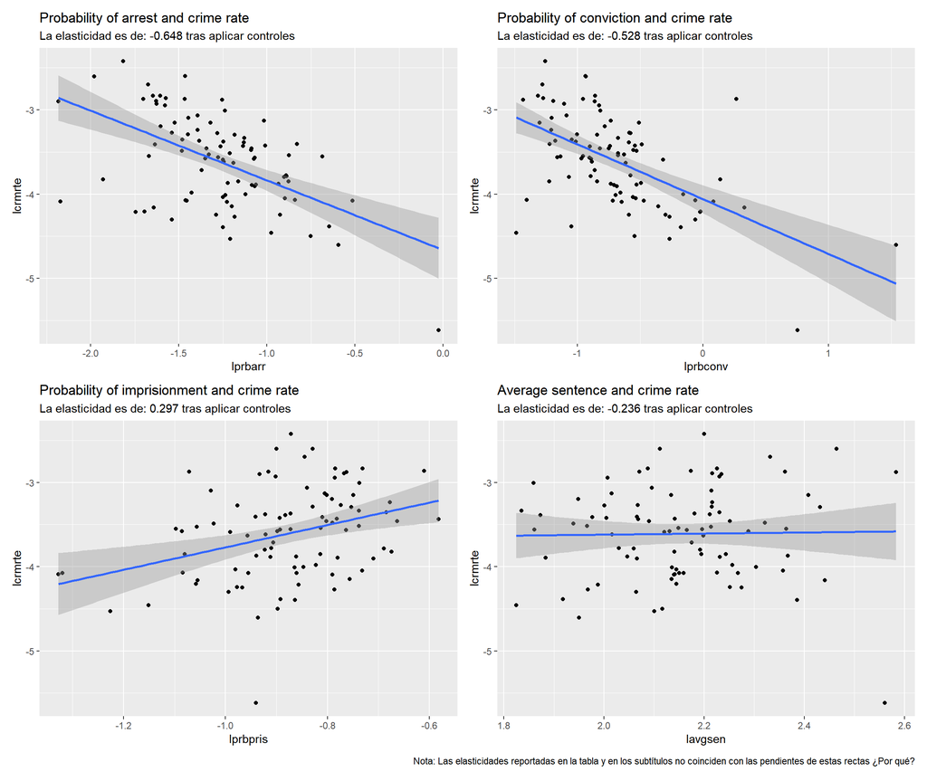

```r
## Veamos unos graficos simples de la data antes de seguir.

### Primero creemos un data.frame con todos los coeficietnes del modelo. Esto podremos pegarlo despues en la parte del grafico que prefiramos.
coeficientes<-BE_model_amano %>%
  modelsummary::tidy() %>%
  select(term,estimate)

### Ahora veamos la distribucion conjunta de cada variable y la tasa de criminalidad.
p1<-cornwell_between %>%
  ggplot(aes(y=lcrmrte,x=lprbarr))+
  geom_point()+
  geom_smooth(method = "lm")+
  labs(title="Probability of arrest and crime rate",
       subtitle = paste0("La elasticidad es de: ", round(filter(coeficientes,term=="lprbarr")$estimate,3)," tras aplicar controles"))

p2<-cornwell_between %>%
  ggplot(aes(y=lcrmrte,x=lprbconv))+
  geom_point()+
  geom_smooth(method = "lm")+
  labs(title="Probability of conviction and crime rate",
       subtitle = paste0("La elasticidad es de: ", round(filter(coeficientes,term=="lprbconv")$estimate,3)," tras aplicar controles"))

p3<-cornwell_between %>%
  ggplot(aes(y=lcrmrte,x=lprbpris))+
  geom_point()+
  geom_smooth(method = "lm")+
  labs(title="Probability of imprisionment and crime rate",
       subtitle = paste0("La elasticidad es de: ", round(filter(coeficientes,term=="lprbpris")$estimate,3)," tras aplicar controles"))

p4<-cornwell_between %>%
  ggplot(aes(y=lcrmrte,x=lavgsen))+
  geom_point()+
  geom_smooth(method = "lm")+
  labs(title="Average sentence and crime rate",
       subtitle = paste0("La elasticidad es de: ", round(filter(coeficientes,term=="lavgsen")$estimate,3)," tras aplicar controles"))


(p1+p2)/(p3+p4)+plot_annotation(caption = "Nota: Las elasticidades reportadas en la tabla y en los subtítulos no coinciden con las pendientes de estas rectas ¿Por qué?")
```

## 2. Posibles problemas de heterogeneidad no observable y el estimador de efectos fijos (FE)

```r
#-------------------------------------------#
# Within Model (Table 3 Cornwell)
#-------------------------------------------#

# Aca usamos los datos within que creeamos arriba. Usamos la funcion de regresion lineal mas sencilla que hay
FE_model_a_mano <- lm(lcrmrte ~ lprbarr+lprbconv+lprbpris+lavgsen+lpolpc+ldensity+lpctymle+lwcon+lwtuc+lwtrd+
                  lwfir+lwser+lwmfg+lwfed+lwsta+lwloc+west+central+urban+lpctmin,
                data = cornwell_within)

# Aca usamos la data original, pero añadimos una variable binaria por cada condado insertando la variable (county) en la formula en formato factor (es muy importante que no esté en formato numerico ¿Por que?)
FE_model_a_mano_ii <- lm(lcrmrte ~ lprbarr+lprbconv+lprbpris+lavgsen+lpolpc+ldensity+lpctymle+lwcon+lwtuc+lwtrd+
                  lwfir+lwser+lwmfg+lwfed+lwsta+lwloc+west+central+urban+lpctmin+
                    factor(county),
                data = cornwell_within)

# Acá usamos la función plm del paquete plm, especificandole que queremos el estimador within
FE_model <- plm(lcrmrte ~ lprbarr+lprbconv+lprbpris+lavgsen+lpolpc+ldensity+lpctymle+lwcon+lwtuc+lwtrd+
                  lwfir+lwser+lwmfg+lwfed+lwsta+lwloc+west+central+urban+lpctmin,
                data = cornwell_data, index=c("county", "year"), model="within")
library(fixest)
FE_model_2 <- feols(lcrmrte ~ lprbarr+lprbconv+lprbpris+lavgsen+lpolpc+ldensity+lpctymle+lwcon+lwtuc+lwtrd+
                  lwfir+lwser+lwmfg+lwfed+lwsta+lwloc+west+central+urban+lpctmin | county,
                data = cornwell_data)
# También valdría la pena replicarlo con el paquete fixest

## El punto de mostrar tres maneras es que notes que son equivalentes.
## De las tres, quizás la mas transparente es la segunda, pero es la mas ineficiente.
## Se recomiendo usar bien sea la tercera o la cuarta, sobretodo por la flexibilidad que tendran para ajustar sus errores estandar de alguna manera.

msummary(list("Crime rate (metodo manual)"=FE_model_a_mano,
              "Crime rate (metodo manual 2)"=FE_model_a_mano_ii,
              "Crime rate (plm package)"=FE_model,
              "Crime rate (feols function)"=FE_model_2),
         stars = c('*' = .1, '**' = .05, '***' = .01),
         coef_map = c('lprbarr' = 'Log prob. arr.',
                         'lprbconv' = 'Log prob. conv.',
                         'lprbpris'=" Log prob. pris.",
                         'lavgsen'='Log avg. sen.',
                      ## Chicos, aun quiero ver el coeficiente de urban, west y central.
                      ## Alguno sabe por que no salen los coeficientes?
                      ## Pista: No es un error de programacion, piensen en la version within de estas variables.
                      'urban'="Urban",
                      'west'="West",
                      'central'="Central"),
         gof_map= modelsummary::gof_map %>%
           filter(raw=="nobs"|raw=="r.squared"| raw=="within.r.squared"))
```

|  | Crime rate (metodo manual) | Crime rate (metodo manual 2) | Crime rate (plm package) | Crime rate (feols function) |
| --- | --- | --- | --- | --- |
| Log prob. arr. | -0.385*** | -0.385*** | -0.385*** | -0.385*** |
|  | (0.030) | (0.033) | (0.033) | (0.060) |
| Log prob. conv. | -0.301*** | -0.301*** | -0.301*** | -0.301*** |
|  | (0.020) | (0.021) | (0.021) | (0.049) |
| Log prob. pris. | -0.191*** | -0.191*** | -0.191*** | -0.191*** |
|  | (0.030) | (0.033) | (0.033) | (0.045) |
| Log avg. sen. | 0.026 | 0.026 | 0.026 | 0.026 |
|  | (0.023) | (0.025) | (0.025) | (0.032) |
| Num.Obs. | 630 | 630 | 630 | 630 |
| R2 | 0.425 | 0.425 | 0.425 | 0.950 |
| R2 Within |  |  |  | 0.425 |

* p < 0.1, ** p < 0.05, *** p < 0.01

El efecto de controlar por condado hace que las estimaciones (en valor absoluto) de las variables de justicia disminuyan. Por ejemplo, la elasticidad estimada de la variables $P_{A}$ y $P_{C}$ disminuyeron en un $41 \%$ y 43 , respectivamente. A diferencia de las estimaciones between, el coeficiente $P_{P}$ estimado por efectos fijos tiene el signo correcto (negativo) y es significativo estadísticamente. Al igual que en el caso anterior, la estimación del parámetro $S$ es no significativa y de baja magnitud. Además, se pudo observar que los efectos disuasivos estimados se pueden ordenar según el modelo económico del crimen $\left(\left|P_{A}\right|>\left|P_{C}\right|>\left|P_{P}\right|\right)$.

Tal y como indican Cornwell y Trumbull, la omisión de efectos por condado generan grandes diferencias en las estimaciones (en este caso entre BE y FE).

# Referencias

Cornwell, C. y Trumbull, W. (1994). Estimating the Economic Model of Crime with Panel Data. The Review of Economics and Statistics 76(2): 360 - 366.

Wooldridge, J. M. (2013). Introductory Econometrics: A Modern Approach. 5th ed. Mason, OH: South-Western Cengage Learning.

Walter Sosa Escudero. Seminarios en Universidad de San Andrés y Universidad de La Plata. link